# No Show Appointment Data Exploration

## Introduction

This dataset consist of over 110,000 medical appointments collected in Brazil and is focused on the question of whether or not patients show up for their appointment. A number of characteristics about the patient are included in each row.

> **Supporting Material**: No Show Appointment

> **Data Source**: [Kaggle](https://www.google.com/url?q=https://www.kaggle.com/joniarroba/noshowappointments&sa=D&source=editors&ust=1653562576691069&usg=AOvVaw1NcnXiqZwomcljy7DxTZWW)

## Preliminary Wrangling

This document explores a dataset containing no show and attributes for approximately 110,527 medical appointments.

```python
# import all packages and set plots to be embedded inline
import numpy as np
import pandas as pd
import matplotlib.pyplot as plt
import seaborn as sb

%matplotlib inline
```

```python
# load in the dataset into a pandas dataframe, print statistics
no_show_app = pd.read_csv('noshowappointments-kagglev2-may-2016.csv')
```

```python
# high-level overview of data shape and composition
print(no_show_app.shape)
print(no_show_app.dtypes)
print(no_show_app.head(5))
```

```
(110527, 14)
PatientId         float64
AppointmentID       int64
Gender             object
ScheduledDay       object
AppointmentDay     object
Age                 int64
Neighbourhood      object
Scholarship         int64
Hipertension        int64
Diabetes            int64
Alcoholism          int64
Handcap             int64
SMS_received        int64
No-show            object
dtype: object
      PatientId  AppointmentID Gender          ScheduledDay  \
0  2.987250e+13        5642903      F  2016-04-29T18:38:08Z
1  5.589978e+14        5642503      M  2016-04-29T16:08:27Z
2  4.262962e+12        5642549      F  2016-04-29T16:19:04Z
3  8.679512e+11        5642828      F  2016-04-29T17:29:31Z
4  8.841186e+12        5642494      F  2016-04-29T16:07:23Z

         AppointmentDay  Age      Neighbourhood  Scholarship  Hipertension  \
0  2016-04-29T00:00:00Z   62    JARDIM DA PENHA            0             1
1  2016-04-29T00:00:00Z   56    JARDIM DA PENHA            0             0
2  2016-04-29T00:00:00Z   62      MATA DA PRAIA            0             0
3  2016-04-29T00:00:00Z    8  PONTAL DE CAMBURI            0             0
4  2016-04-29T00:00:00Z   56    JARDIM DA PENHA            0             1

   Diabetes  Alcoholism  Handcap  SMS_received No-show
0         0           0        0             0      No
1         0           0        0             0      No
2         0           0        0             0      No
3         0           0        0             0      No
4         1           0        0             0      No
```

I will convert the Patient ID and Appointment ID to string type instead of float and integer because the numeric value are meant for Identication number and we won't be carrying any statistical work on them.

```python
# convert patientid and appointmentid to str instead of float and int recpectively since they are just meant for identification
no_show_app['PatientId'] = no_show_app['PatientId'].astype('int64').astype(str).str.zfill(15)

no_show_app['AppointmentID'] = no_show_app['AppointmentID'].astype(str)

print(no_show_app[['PatientId', 'AppointmentID']].sample(2))
print(no_show_app[['PatientId', 'AppointmentID']].dtypes)
```

```
              PatientId AppointmentID
101072  043484477581826       5666369
56293   044912857562224       5703072
PatientId        object
AppointmentID    object
dtype: object
```

I will also convert Scheduled date and Appointment date to Datetime ns instead of string and also remove the time from the schedule date to make it consistent

```python
# convert scheduled_date and appointment_date to datetime instead of string
date_columns = ['ScheduledDay', 'AppointmentDay']

for date_column in date_columns:
    no_show_app[date_column] = pd.to_datetime(no_show_app[date_column]).dt.date.astype('datetime64[ns]')

print(no_show_app[['ScheduledDay', 'ScheduledDay']].sample(5))
```

```
      ScheduledDay ScheduledDay
55890   2016-05-09   2016-05-09
81021   2016-04-29   2016-04-29
50764   2016-04-18   2016-04-18
69115   2016-04-25   2016-04-25
95305   2016-06-08   2016-06-08
```

It seems while the data a been computed they mistakenly interchange sms received with handicap value. So, the two columns with be swap for each other while renaming and correcting the misspelled columns.

```python
# rename misspelled columns and change all columns to lowercase for consistence
# also interchange sms received and handicap (handicap can't have a value more than 0 and 1 i.e. No and Yes)
no_show_app.rename(columns = {'ScheduledDay':'Scheduled_Date', 'AppointmentDay':'Appointment_Date',
                              'Hipertension':'Hypertension','SMS_received':'Handicap', 'Handcap':'SMS_received',
                              'No-show':'No_show'}, inplace=True)

no_show_app.rename(columns= lambda x: x.lower(), inplace=True)

no_show_app.columns
```

```
Index(['patientid', 'appointmentid', 'gender', 'scheduled_date',
       'appointment_date', 'age', 'neighbourhood', 'scholarship',
       'hypertension', 'diabetes', 'alcoholism', 'sms_received', 'handicap',
       'no_show'],
      dtype='object')
```

```python
# convert gender, scholarship, hypertension, diabetes, alcoholism, handicap, and no_show into categorical types
nominal_var_dict = {'gender': ['M','F'],
                    'scholarship': [0, 1],
                    'hypertension': [0, 1],
                    'diabetes': [0, 1],
                    'alcoholism': [0, 1],
                    'handicap': [0, 1],
                    'no_show': ['No', 'Yes']}

for var in nominal_var_dict:
    nominal_var = pd.api.types.CategoricalDtype(categories = nominal_var_dict[var])
    no_show_app[var] = no_show_app[var].astype(nominal_var)
```

I will need the day the appointment date falls in order to help me in my investigation, and also the number of days the patients have to wait from the date thier appointment was scheduled to appointment date

```python
# create a new column appointment day of the week to help in my investigation
no_show_app['appointment_day'] = pd.to_datetime(no_show_app['appointment_date']).dt.day_name()


dow = ['Monday', 'Tuesday', 'Wednesday', 'Thursday', 'Friday', 'Saturday']
days = pd.api.types.CategoricalDtype(categories=dow, ordered=True)
no_show_app['appointment_day'] = no_show_app['appointment_day'].astype(days)
```

```python
# Create another column for waiting days (appointment_date - schedule_date)
no_show_app['waiting_days'] = no_show_app['appointment_date'] - no_show_app['scheduled_date']

no_show_app['waiting_days'] = no_show_app['waiting_days'].dt.days
```

```python
#this bin egdes will be used to cut the data into groups
bin_edges = [-1, 5, 12, 18, 40, 60, 115]

#label for the age group
bin_names = ['Early Childhood', 'Middle Childhood', 'Adolescence', 'Youthhood', 'Middle Age', 'Old Age']

no_show_app['age_group'] = pd.cut(no_show_app['age'], bin_edges, labels=bin_names, ordered=True)
```

```python
print(no_show_app.describe())
```

```
                 age   sms_received   waiting_days
count  110527.000000  110527.000000  110527.000000
mean       37.088874       0.022248      10.183702
std        23.110205       0.161543      15.254996
min        -1.000000       0.000000      -6.000000
25%        18.000000       0.000000       0.000000
50%        37.000000       0.000000       4.000000
75%        55.000000       0.000000      15.000000
max       115.000000       4.000000     179.000000
```

```python
# drop negative value of age and waiting days columns, then reset and drop index
no_show_app = no_show_app[(no_show_app['age'] >= 0) & (no_show_app['waiting_days'] >= 0)]
no_show_app = no_show_app.reset_index(drop=True)
```

```python
# high-level overview of data shape and composition
print(no_show_app.shape)
print(no_show_app.dtypes)
```

```
(110521, 17)
patientid                   object
appointmentid               object
gender                    category
scheduled_date      datetime64[ns]
appointment_date    datetime64[ns]
age                          int64
neighbourhood               object
scholarship               category
hypertension              category
diabetes                  category
alcoholism                category
sms_received                 int64
handicap                  category
no_show                   category
appointment_day           category
waiting_days                 int64
age_group                 category
dtype: object
```

### What is the structure of your dataset?

Moreove, there are two oridnal category variable which are `appointment_day` and `age_group` with the following values.

- `appointment_day`: Monday, Tuesday, Wednesday, Thursday, Friday and Saturday (working days for hospitals)
- `age_group`: Early Childhood, Middle Childhood, Adolescence, Youthhood, Middle Age, Old Age

### What is/are the main feature(s) of interest in your dataset?

I'm most interested in figuring out what features are best for predicting the reason why patients will book an appointment and yet still not show up for the appointment in the dataset.

### What features in the dataset do you think will help support your investigation into your feature(s) of interest?

I expect that waiting_days will have the strongest effect on each patient's no_show. I also think other factors like age, scholarship, hypertension, diabetes, alcholism, handicap, sms_received, appointment_day and age_group will have effects on patients reponses to no_show though to a much smaller degree than the main effect of waiting_days.

## Univariate Exploration

I will start by looking that the distribution of the variable of interest: no_show.

Therefore, I will write a function to plot a barchart to help me reduce repetition of codes.

```python
def barchart_percent(var, figsize=[6.4, 4.8], yaxis=False, ordered=False):
    '''seaborn bar chart
    var - the column to plot,
    figsize - optional but can be provided
    yaxis=False - it means to plot on yaxis but if True
    it will be plotted on yaxis
    order=False | bool value - it means to plot according
    to the highest value
    '''
    plt.figure(figsize=figsize)
    base_color = sb.color_palette()[0]

    # Count the frequency of unique values  and return the sum of all value in the var column of no_show_app dataframe.
    var_counts = no_show_app[var].value_counts()
    var_order = no_show_app[var].value_counts().index
    n_var = no_show_app[var].value_counts().sum()

    # Return the highest frequency in the var column
    max_var_count = var_counts[0]

    # Return the maximum proportion, or in other words,
    # compute the length of the longest bar in terms of the proportion
    max_prop = max_var_count/n_var

    if not yaxis:
        if not ordered:
            sb.countplot(data=no_show_app, x=var, color=base_color)
            # get the current tick locations and labels
            locs, labels = plt.xticks()

            # loop through each pair of locations and labels
            for loc, label in zip(locs, labels):

                # get the text property for the label to get the correct count
                count = var_counts[label.get_text()]
                pct_string = '{:0.1f}%'.format(100*count/n_var)

                # print the annotation just below the top of the bar
                plt.text(loc, count+2, pct_string, ha='center', color='black')
            plt.show();
        else:
            sb.countplot(data=no_show_app, x=var, color=base_color, order=var_order)
            # get the current tick locations and labels
            locs, labels = plt.xticks()

            # loop through each pair of locations and labels
            for loc, label in zip(locs, labels):

                # get the text property for the label to get the correct count
                count = var_counts[label.get_text()]
                pct_string = '{:0.1f}%'.format(100*count/n_var)

                # print the annotation just below the top of the bar
                plt.text(loc, count+2, pct_string, ha='center', color='black')
            plt.show();
    else:
        if not ordered:
            sb.countplot(data=no_show_app, y=var, color=base_color)

            # get the current tick locations and labels
            locs, labels = plt.yticks()

            for loc, label in zip(locs, labels):

                # get the text property for the label to get the correct count
                count = var_counts[label.get_text()]
                pct_string = '{:0.1f}%'.format(100*count/n_var)

                # print the annotation just below the top of the bar
                plt.text(count+2, loc, pct_string, va='center', color='black')
            plt.show();
        else:
            sb.countplot(data=no_show_app, y=var, color=base_color, order=var_order)
            for i in range(var_counts.shape[0]):
                # Remember, type_counts contains the frequency of unique values in the var column in decreasing order.
                count = var_counts[i]
                # Convert count into a percentage, and then into string
                pct_string = '{:0.1f}%'.format(100*count/n_var)
                plt.text(count+1, i, pct_string, va='center')
            plt.show();
```

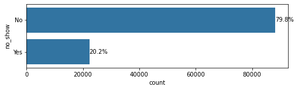

```python
barchart_percent('no_show', [8,2], yaxis=True, ordered=True)
```

This show that about 80% out of over 110,000 patients showed up for their appointment while the remaining 20% refuses to show up. With this for now, we can't conclude why they didn't show up.

Next up, the first predictor variable of interest: waiting_days.

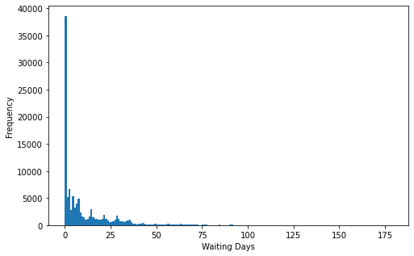

```python
# standard-scaled plot
binsize = 1
bins = np.arange(0, no_show_app['waiting_days'].max()+binsize, binsize)

plt.figure(figsize=[8, 5])
plt.hist(data = no_show_app, x = 'waiting_days', bins = bins)
plt.xlabel('Waiting Days')
plt.ylabel('Frequency')
plt.show();
```

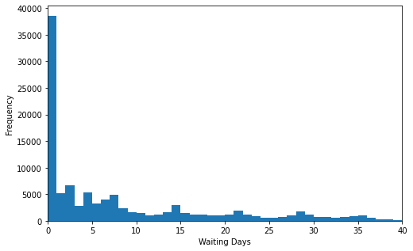

```python
# reduce the x lim
binsize = 1
bins = np.arange(0, no_show_app['waiting_days'].max()+binsize, binsize)

plt.figure(figsize=[8, 5])
plt.hist(data = no_show_app, x = 'waiting_days', bins = bins)
plt.xlim([0, 40])
plt.xlabel('Waiting Days')
plt.ylabel('Frequency')
plt.show();
```

I will move on the other variables in the dataset: age, sms_received

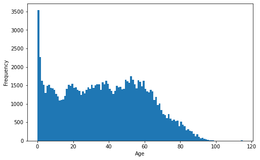

```python
# start with a standard-scaled plot
binsize = 1
bins = np.arange(0, no_show_app['age'].max()+binsize, binsize)

plt.figure(figsize=[8, 5])
plt.hist(data = no_show_app, x = 'age', bins = bins)
plt.xlabel('Age')
plt.ylabel('Frequency')
plt.show()
```

Age has a long-tailed distribution, with a lot of patients on the lower age end, and few on the higher age end, it seems to be multimodal with the highest peak around 0 and 2, Afterward, there is a steep fall in frequency rather than a smooth ramp down.

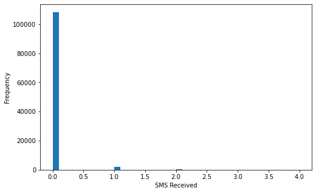

```python
# start with full plot asix
binsize = 0.1
bins = np.arange(0, no_show_app['sms_received'].max()+binsize, binsize)

plt.figure(figsize=[8, 5])
plt.hist(data = no_show_app, x = 'sms_received', bins = bins)
plt.xlabel('SMS Received')
plt.ylabel('Frequency')
plt.show();
```

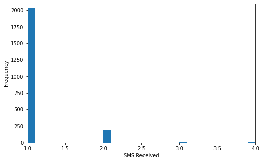

```python
# with xlim and ylim
binsize = 0.1
bins = np.arange(0, no_show_app['sms_received'].max()+binsize, binsize)

plt.figure(figsize=[8, 5])
plt.hist(data = no_show_app, x = 'sms_received', bins = bins)
plt.xlim([1,4])
plt.ylim([0,2100])
plt.xlabel('SMS Received')
plt.ylabel('Frequency')
plt.show();
```

This show that the number of sms received by a patients are very fews compare to the number of patients that doesn't recevied sms at all.

I will look into other categorical variables: gender, appointment_day, age_group, scholarship and the remaining categorical variables.

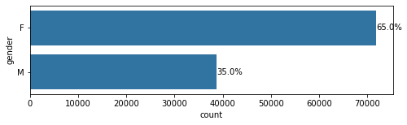

```python
barchart_percent('gender', [8,2], yaxis=True, ordered=True)
```

This shows that the are more female than male in the dataset. The famales are of two-third while the male are one-third.

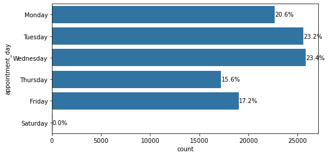

```python
barchart_percent('appointment_day', [8,4],yaxis=True)
```

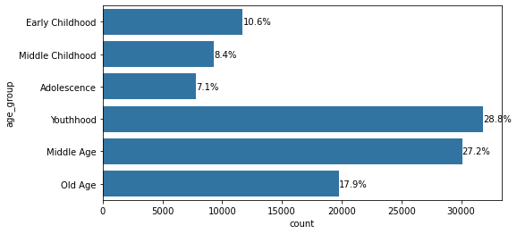

```python
barchart_percent('age_group', [8,4], yaxis=True)
```

There are more patients in the Adulthood stages (>= 18yrs) compare to the childhood stage (< 18 yrs). As the age group increase for childhood the number of patients reduced, same applies to the adulthood.

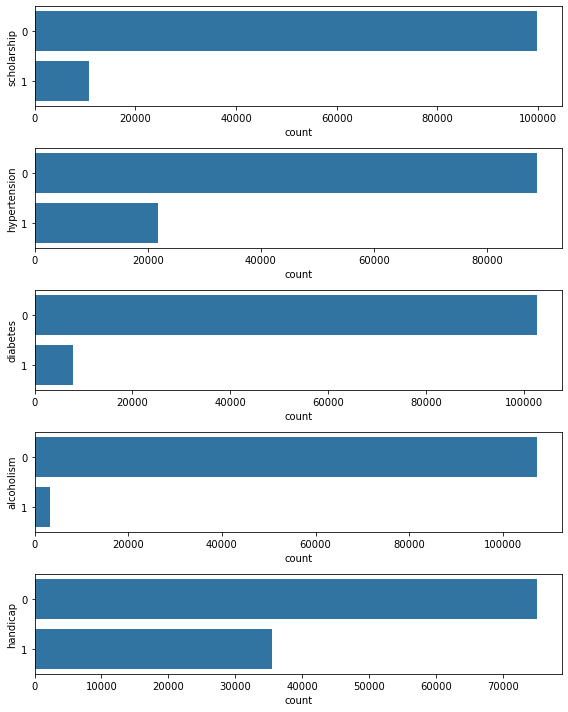

```python
# let's plot all three together to get an idea of each ordinal variable's distribution.


fig, ax = plt.subplots(nrows=5, figsize = [8,10])

bool_var = ['scholarship', 'hypertension', 'diabetes', 'alcoholism', 'handicap']
base_color = sb.color_palette()[0]

for i in range(len(bool_var)):
    var = bool_var[i]
    sb.countplot(data = no_show_app, y = var, color = base_color, ax = ax[i])
    plt.tight_layout()
plt.show()
```

There are more patients without scholarship, and more patients with no hypertention, diabetes, alcholism compare with handicap variable which have record of ratio 1 to 2 patients of True and False.

### Of the features you investigated, were there any unusual distributions? Did you perform any operations on the data to tidy, adjust, or change the form of the data? If so, why did you do this?

There was `age` with negative of 1 and `waiting_days` with about 5 values with negative numbers but were dropped when preparing the dataset. When plotted it wasn't reflecting on the graph because they were just 6 in total compare to the whole value of over 110,000 of `age` and of `waiting_days` repectively.

## Bivariate Exploration

To start off with, I want to look at the pairwise correlations present between features in the data.

```python
numeric_vars = ['age', 'sms_received', 'waiting_days']
gen_sch_vars = ['gender', 'scholarship',]
sym_cat_vars = ['hypertension', 'diabetes', 'alcoholism', 'handicap']
cat_vars = ['no_show', 'appointment_day', 'age_group']
```

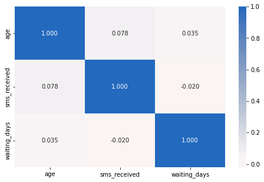

```python
plt.figure(figsize=[8,5])
sb.heatmap(no_show_app[numeric_vars].corr(), annot= True, fmt = '.3f', cmap='vlag_r',
           center= 0)
plt.show;
```

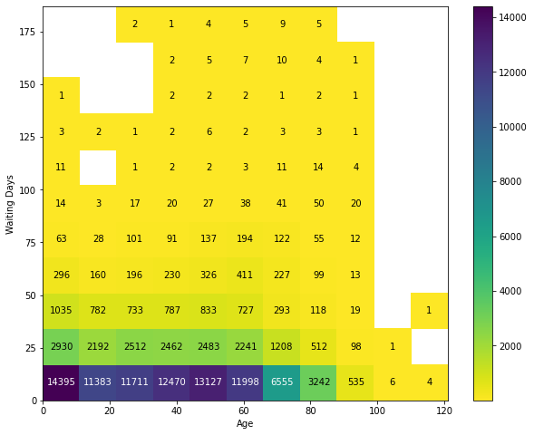

```python
plt.figure(figsize=[10,8])
# bin edges
bins_x = np.arange(0, 115+11, 11)
bins_y = np.arange(0, 179+17, 17)

h2d = plt.hist2d(data = no_show_app, x = 'age', y = 'waiting_days',
                 cmin=0.5, cmap='viridis_r', bins = [bins_x, bins_y])

plt.colorbar()
plt.xlabel('Age')
plt.ylabel('Waiting Days');

counts = h2d[0]

# Add text annotation on each cell
# Loop through the cell counts and add text annotations for each
for i in range(counts.shape[0]):
    for j in range(counts.shape[1]):
        c = counts[i,j]
        if c >= 3500: # increase visibility on darker cells
            plt.text(bins_x[i]+5.5, bins_y[j]+8.5, int(c),
                     ha = 'center', va = 'center', color = 'white')
        elif c > 0:
            plt.text(bins_x[i]+5.5, bins_y[j]+8.5, int(c),
                     ha = 'center', va = 'center', color = 'black')
```

Let's look on how other categorical variable affect no show appointment by waiting days and age.

```python
def barplot(cat_v, nrows=1, figsize = [10,12]):
    base_color = sb.color_palette()[0]
    fig, ax = plt.subplots(ncols = 2, nrows = nrows , figsize = figsize)

    for i in range(len(cat_v)):
        var = cat_v[i]
        sb.barplot(data = no_show_app, x = var, y = 'age', ax = ax[i,0],
                   color = base_color)
        sb.barplot(data = no_show_app, x = var, y = 'waiting_days', ax = ax[i,1],
                   color = base_color)

    plt.show();
```

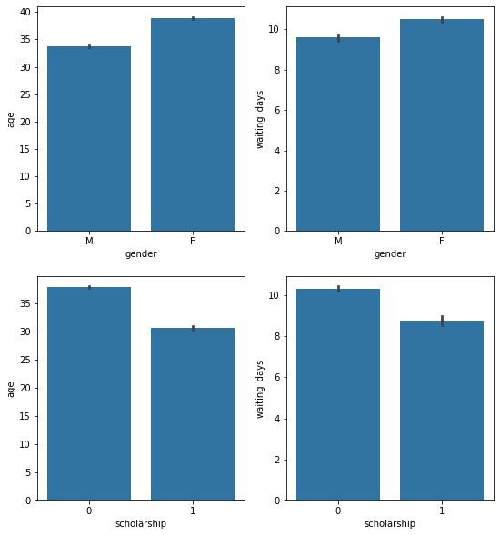

```python
barplot(gen_sch_vars, 2, [9,10])
```

The average age and average waiting days of female are more compare to that of male and these might be because the frequency of female are more than that of man. The scholarship by average age and average waiting days also shows that those without scholarship are more than those with scholarship.

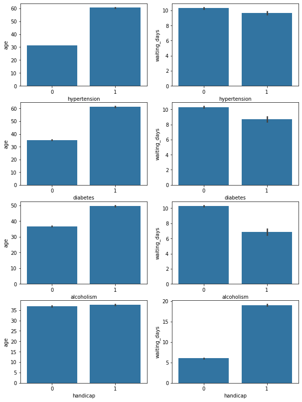

```python
barplot(sym_cat_vars, 4, [10,14])
```

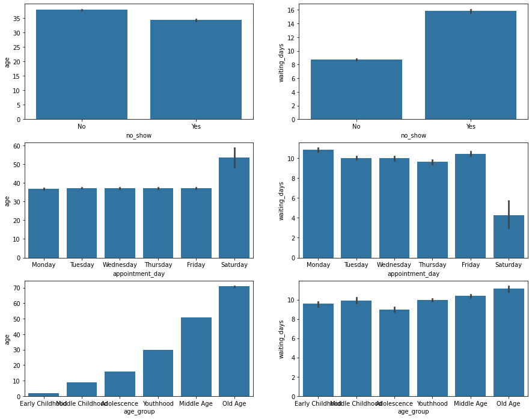

```python
barplot(cat_vars, 3, [15,12])
```

Waiting days by no show variable seems affect the decision of patients in showing up compare to other categorical variables. There are about 8 average days for patients who showed up compare to patients who doesn't show up with the average days of 16.

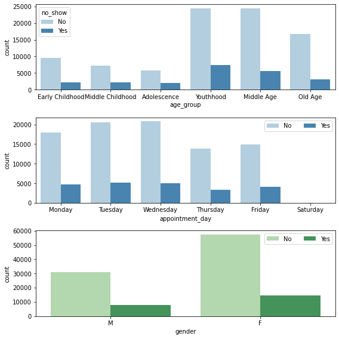

```python
# since there's only three subplots to create, using the full data should be fine.
plt.figure(figsize = [8, 8])

# subplot 1: age_group vs no_show
plt.subplot(3, 1, 1)
sb.countplot(data = no_show_app, x = 'age_group', hue = 'no_show', palette = 'Blues')

# subplot 2: appointment_day vs. no_show
ax = plt.subplot(3, 1, 2)
sb.countplot(data = no_show_app, x = 'appointment_day', hue = 'no_show', palette = 'Blues')
ax.legend(ncol = 2) # re-arrange legend to reduce overlapping

# subplot 3: gender vs. no_show, use different color palette
ax = plt.subplot(3, 1, 3)
sb.countplot(data = no_show_app, x = 'gender', hue = 'no_show', palette = 'Greens')
ax.legend(loc = 1, ncol = 2) # re-arrange legend to remove overlapping
plt.tight_layout()
plt.show()
```

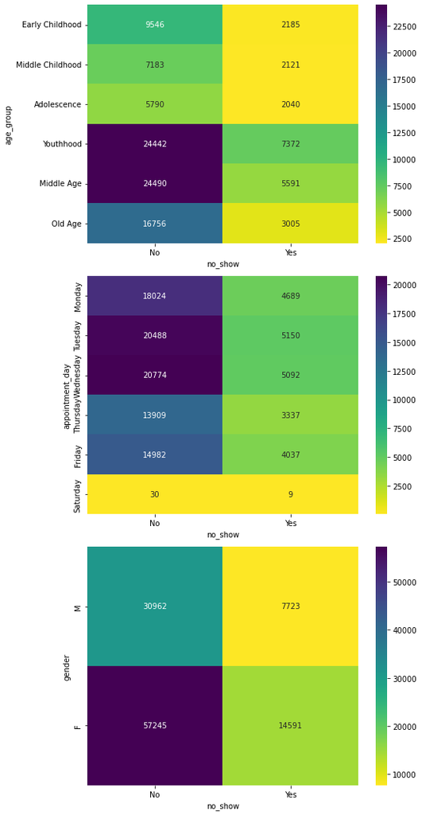

```python
fig, ax = plt.subplots(nrows=3, figsize = [8,15])

cat_variables = ['age_group', 'appointment_day', 'gender']

for i in range(len(cat_variables)):
    var = cat_variables[i]
    ct_counts = no_show_app.groupby([var,
                                      'no_show']).size().reset_index(name='count').pivot(index=var,
                                                                                         columns='no_show', values='count')
    sb.heatmap(ct_counts, annot=True, fmt='d', cmap='viridis_r', ax = ax[i])
    plt.tight_layout()
plt.show();
```

There doesn't seem to be much interaction between no_show variable and age group, appointment day, gender variable. As we can see that the ratio of show and no show along each variables' value are closely alike despite the large value it takes.

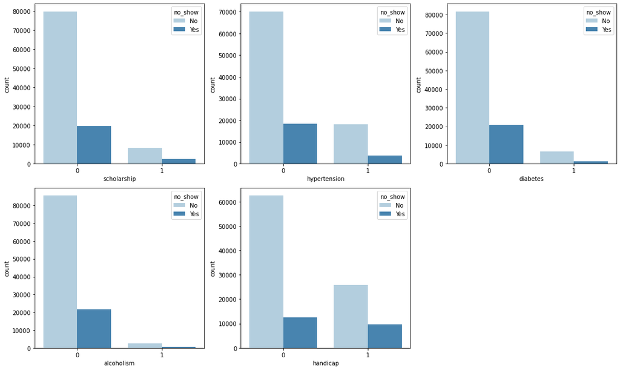

```python
# since there's only three subplots to create, using the full data should be fine.
plt.figure(figsize = [15, 9])

# subplot 1: scholarship vs no_show
plt.subplot(2, 3, 1)
sb.countplot(data = no_show_app, x = 'scholarship', hue = 'no_show', palette = 'Blues')

# subplot 2: hypertension vs. no_show
ax = plt.subplot(2, 3, 2)
sb.countplot(data = no_show_app, x = 'hypertension', hue = 'no_show', palette = 'Blues')

# subplot 3: diabetes vs. no_show
ax = plt.subplot(2, 3, 3)
sb.countplot(data = no_show_app, x = 'diabetes', hue = 'no_show', palette = 'Blues')

# subplot 4: alcoholism vs. no_show
ax = plt.subplot(2, 3, 4)
sb.countplot(data = no_show_app, x = 'alcoholism', hue = 'no_show', palette = 'Blues')

# subplot 5: handicap vs. no_show
ax = plt.subplot(2, 3, 5)
sb.countplot(data = no_show_app, x = 'handicap', hue = 'no_show', palette = 'Blues')
plt.tight_layout()
plt.show()
```

### Talk about some of the relationships you observed in this part of the investigation. How did the feature(s) of interest vary with other features in the dataset?

This will have to be explored further in the next section.

### Did you observe any interesting relationships between the other features (not the main feature(s) of interest)?

Every other booleean variables of additional symptoms and disabilities should have help in forward in exploring but they are not more detailed here but maybe when explored further in the next section, the relationship they have on no show of patients might be seem.

## Multivariate Exploration

Explore

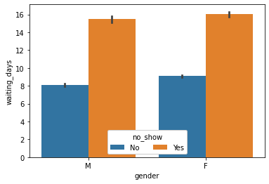

```python
ax = sb.barplot(data = no_show_app, x = 'gender', y = 'waiting_days', hue = 'no_show')
ax.legend(loc = 8, ncol = 3, framealpha = 1, title = 'no_show');
```

Even this still shows that the avearge waiting days of those who did not show up for their appointment by gender are still of the same value from the previous plot above in bivariate section falling between 15 and 16 average waiting days for both male and female.

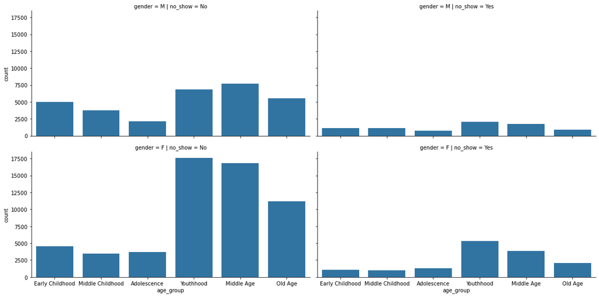

```python
# facegrid no_show and gender by age group
g = sb.FacetGrid(no_show_app, col="no_show",  row="gender", height=4, aspect=2)
g.map(sb.countplot, "age_group");
```

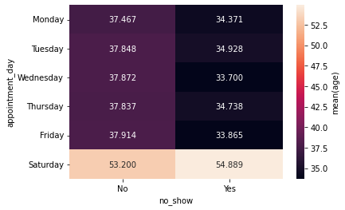

```python
cat_means = no_show_app.groupby(['no_show', 'appointment_day']).mean()['age']
cat_means = cat_means.reset_index(name = 'age_avg')
cat_means = cat_means.pivot(index = 'appointment_day', columns = 'no_show',
                            values = 'age_avg')
sb.heatmap(cat_means, annot = True, fmt = '.3f',
           cbar_kws = {'label' : 'mean(age)'});
```

Average age of those who doesn't show up on Saturday of the appointment day seems to be the highest among the remaining days despite having a very lower record of patients.

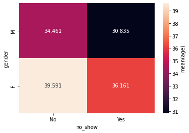

```python
cat_means = no_show_app.groupby(['no_show', 'gender']).mean()['age']
cat_means = cat_means.reset_index(name = 'age_avg')
cat_means = cat_means.pivot(index = 'gender', columns = 'no_show',
                            values = 'age_avg')
sb.heatmap(cat_means, annot = True, fmt = '.3f',
           cbar_kws = {'label' : 'mean(age)'});
```

I could say that gender doesn't play any role in determining whether the patient will show up or not.

### Talk about some of the relationships you observed in this part of the investigation. Were there features that strengthened each other in terms of looking at your feature(s) of interest?

I extended my investigation waitng days of patients against no show up of patients in this section by looking at the impact of the three categorical quality features. The multivariate exploration here showed that there indeed is a positive effect of long waited appointment duration between schedule date and appointment date which discourage patients for showing up.

### Were there any interesting or surprising interactions between features?

Looking back on the heatmap plot, it shows that despite appointment fix for saturday are fews, the percentage of not showing up is high compare to other days of the week.

## Conclusions

And also, the appointment day which is Saturday has lower patients rate and yet still have the higtest rate of not showing up for their appointment.